# Assignment3

Tejaswini Sengaonkar

2023-09-29

```r
library(dplyr)
```

```r
library(ggplot2)
library(lubridate)
```

**Data Loading and Cleaning**

```r
data_week2 <- read.csv("C:/Users/tejas/OneDrive/Desktop/Assignments/STATS 763/Assignment3/week2.csv")
data_week4 <- read.csv("C:/Users/tejas/OneDrive/Desktop/Assignments/STATS 763/Assignment3/week4.csv")

data_clean <- function(data_week2) {
  #remove NA values
  data_week2 <- data_week2 %>%
    na.omit()

  #remove negative fare amount
  data_week2 <- data_week2 %>%
    filter(fare_amount >= 0)

  data_week2 <- data_week2 %>%
    filter(passenger_count != 0)

  data_week2 <- data_week2 %>%
    filter(trip_distance != 0)

  #Data Type Conversion (Convert datetime columns)
  data_week2$tpep_pickup_datetime <- as.POSIXct(data_week2$tpep_pickup_datetime, format = "%Y-%m-%dT%H:%M:%SZ")
  data_week2$tpep_dropoff_datetime <- as.POSIXct(data_week2$tpep_dropoff_datetime, format = "%Y-%m-%dT%H:%M:%SZ")

  #Handling RatecodeID (Remove rows with invalid values)
  data_week2 <- data_week2 %>%
    filter(RatecodeID >= 1 & RatecodeID <= 6)

  #remove invalid payment types
  data_week2 <- data_week2 %>%
    filter(payment_type >= 1 & payment_type <= 4)

  #Remove Inconsistent Data (Remove rows with tpep_dropoff_datetime earlier than tpep_pickup_datetime)
  data_week2 <- data_week2 %>%
    filter(tpep_dropoff_datetime >= tpep_pickup_datetime)

  #Cleaning Geographical Coordinates (Assuming valid range for latitude and longitude)
  data_week2 <- data_week2 %>%
    filter(
      pickup_longitude >= -180 & pickup_longitude <= 180,
      pickup_latitude >= -90 & pickup_latitude <= 90,
      dropoff_longitude >= -180 & dropoff_longitude <= 180,
      dropoff_latitude >= -90 & dropoff_latitude <= 90
    )

  #categorize variables
  data_week2$VendorID <- as.factor(data_week2$VendorID)
  data_week2$payment_type <- as.factor(data_week2$payment_type)
  data_week2$store_and_fwd_flag <- as.factor(data_week2$store_and_fwd_flag)
  data_week2$RatecodeID <-as.factor(data_week2$RatecodeID)

  data_week2 <- data_week2 %>%
    mutate(
      pickup_hour = hour(tpep_pickup_datetime),
      pickup_time_category = case_when(
        pickup_hour >= 5 & pickup_hour < 12 ~ "Morning",
        pickup_hour >= 12 & pickup_hour < 17 ~ "Afternoon",
        pickup_hour >= 17 & pickup_hour < 21 ~ "Evening",
        TRUE ~ "Night"
      ),
      dropoff_hour = hour(tpep_dropoff_datetime),
      dropoff_time_category = case_when(
        dropoff_hour >= 5 & dropoff_hour < 12 ~ "Morning",
        dropoff_hour >= 12 & dropoff_hour < 17 ~ "Afternoon",
        dropoff_hour >= 17 & dropoff_hour < 21 ~ "Evening",
        TRUE ~ "Night"
      )
    ) %>%
    select(-pickup_hour, -dropoff_hour)


  data_week2 <- data_week2 %>%
    mutate(day_of_week = weekdays(tpep_pickup_datetime))

  lat_bins <- c(-Inf, 40.65, 40.75, 40.80, 40.85, 40.7128, Inf)
  lon_bins <- c(-Inf, -74.03, -73.95, -73.90, -73.80, -74.0060, Inf)

  # Define labels for boroughs
  location_labels <- c("Outside NYC", "Bronx", "Manhattan", "Queens", "Brooklyn", "Staten Island")

  # Assign borough labels based on bins for pickup location
  data_week2$pickup_location <- cut(data_week2$pickup_latitude, breaks = lat_bins, labels = location_labels, include.lowest = TRUE)

  # Assign borough labels based on bins for dropoff location
  data_week2$dropoff_location <- cut(data_week2$dropoff_latitude, breaks = lat_bins, labels = location_labels, include.lowest = TRUE)

  data_week2 <- data_week2 %>%
    select(-dropoff_longitude, -dropoff_latitude, -pickup_longitude, -pickup_latitude, -total_amount, -tpep_pickup_datetime, -tpep_dropoff_datetime)

  return(data_week2)
  }

cleaned_week4 <- data_clean(data_week4)
cleaned_week2 <- data_clean(data_week2)

head(cleaned_week2)
```

```
##   VendorID passenger_count trip_distance RatecodeID store_and_fwd_flag
## 1        2               2          1.83          1                  N
## 2        2               1          3.18          1                  N
## 3        2               1          1.17          1                  N
## 4        2               1          5.27          1                  N
## 5        2               1          1.14          1                  N
## 6        2               1          1.70          1                  N
##   payment_type fare_amount extra mta_tax tip_amount tolls_amount
## 1            1        10.0   0.5     0.5       1.50            0
## 2            1        14.5   0.5     0.5       3.16            0
## 3            2         7.0   0.5     0.5       0.00            0
## 4            1        16.5   0.5     0.5       2.00            0
## 5            2         6.0   0.5     0.5       0.00            0
## 6            1         7.5   0.5     0.5       1.76            0
##   improvement_surcharge pickup_time_category dropoff_time_category day_of_week
## 1                   0.3                Night                 Night      Friday
## 2                   0.3                Night                 Night      Friday
## 3                   0.3                Night                 Night      Friday
## 4                   0.3                Night                 Night      Friday
## 5                   0.3                Night                 Night    Saturday
## 6                   0.3                Night                 Night    Saturday
##   pickup_location dropoff_location
## 1       Manhattan        Manhattan
## 2       Manhattan           Queens
## 3          Queens           Queens
## 4          Queens         Brooklyn
## 5          Queens        Manhattan
## 6       Manhattan           Queens
```

```r
head(cleaned_week4)
```

```
##   VendorID passenger_count trip_distance RatecodeID store_and_fwd_flag
## 1        1               2          5.20          1                  N
## 2        2               1          1.13          1                  N
## 3        2               1          5.17          1                  N
## 4        1               1          2.70          1                  N
## 5        1               1          4.60          1                  N
## 6        2               5          2.20          1                  N
##   payment_type fare_amount extra mta_tax tip_amount tolls_amount
## 1            2        19.5   0.5     0.5       0.00            0
## 2            1         6.5   0.5     0.5       1.56            0
## 3            1        17.0   0.5     0.5       3.00            0
## 4            1        11.5   0.5     0.5       2.00            0
## 5            1        16.5   0.5     0.5       3.55            0
## 6            1         9.0   0.5     0.5       2.58            0
##   improvement_surcharge pickup_time_category dropoff_time_category day_of_week
## 1                   0.3                Night                 Night   Wednesday
## 2                   0.3                Night                 Night   Wednesday
## 3                   0.3                Night                 Night   Wednesday
## 4                   0.3                Night                 Night   Wednesday
## 5                   0.3                Night                 Night   Wednesday
## 6                   0.3                Night                 Night   Wednesday
##   pickup_location dropoff_location
## 1       Manhattan            Bronx
## 2          Queens           Queens
## 3       Manhattan           Queens
## 4       Manhattan            Bronx
## 5           Bronx           Queens
## 6       Manhattan        Manhattan
```

Initially, we have loaded the data into two different data frames. In terms of cleaning the data, we have removed the NA value rows, handled negative fare amounts, passenger counts, and trip distances. We have also considered some variables like rate code ID and payment type as factors for analysis purpose. We have cleaned the geographical coordinates and used them to allocate different localitites in New York city.Lastly we have removed inconsistent data and created a variable for week day.

**Data exploration and sampling**

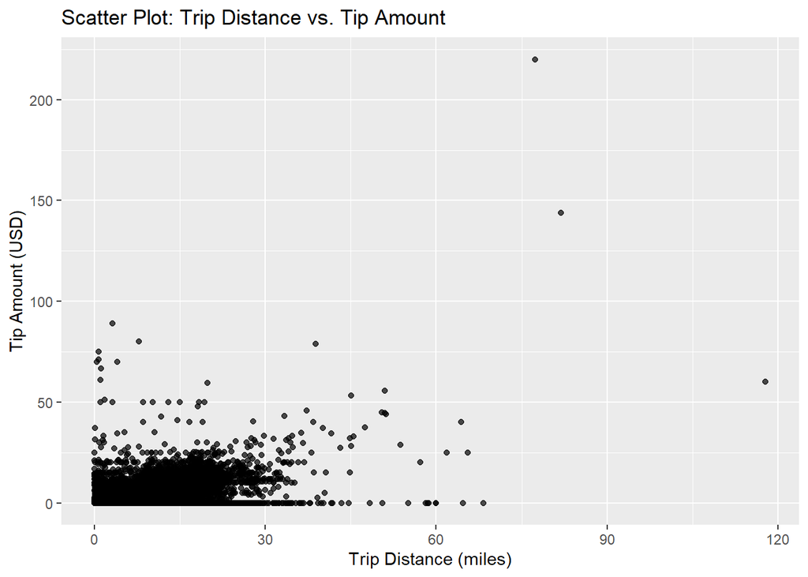

```r
sample_size_training <- round(0.10* nrow(cleaned_week4))
sample_size_testing <- round(0.10* nrow(cleaned_week2))

set.seed(763)
sampled_data_training <- cleaned_week4[sample(seq_len(nrow(cleaned_week4)), size = sample_size_training), ]
sampled_data_testing <- cleaned_week2[sample(seq_len(nrow(cleaned_week2)), size = sample_size_testing), ]
sampled_data_training <- sampled_data_training[]
sampled_data_testing <- sampled_data_testing[]

ggplot(sampled_data_training, aes(x = trip_distance, y = tip_amount)) +
  geom_point(alpha = 0.7) +
  labs(title = "Scatter Plot: Trip Distance vs. Tip Amount",
       x = "Trip Distance (miles)",
       y = "Tip Amount (USD)")
```

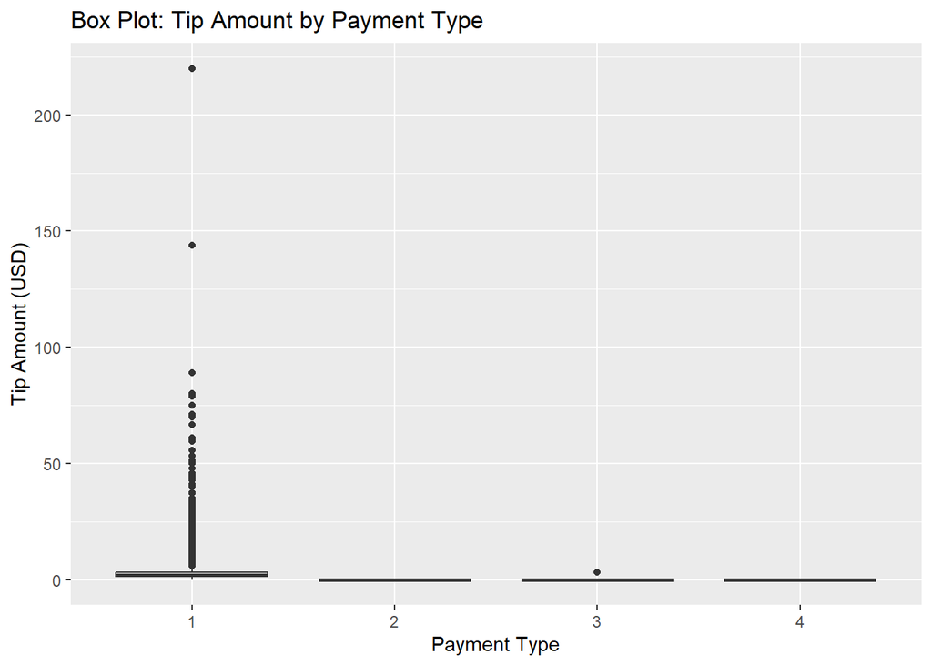

```r
# Box plot to examine the distribution of tip amounts by payment type
ggplot(sampled_data_training, aes(x = payment_type, y = tip_amount)) +
  geom_boxplot() +
  labs(title = "Box Plot: Tip Amount by Payment Type",
       x = "Payment Type",
       y = "Tip Amount (USD)")
```

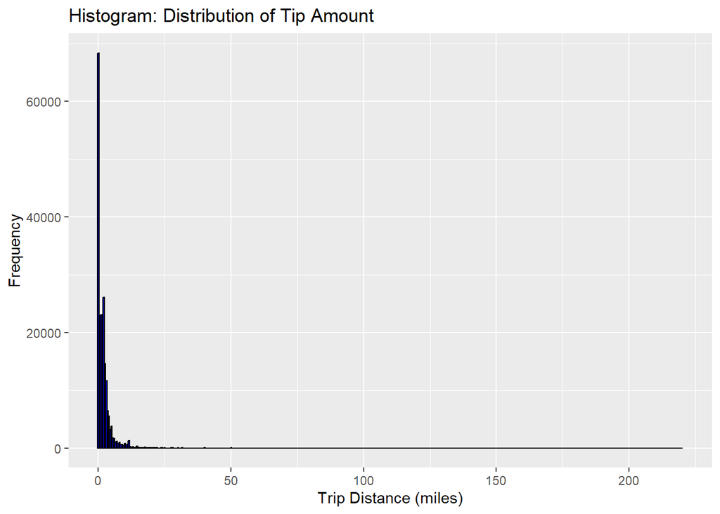

```r
# Histogram to visualize the distribution of trip distances
ggplot(sampled_data_training, aes(x = tip_amount)) +
  geom_histogram(binwidth = 0.5, fill = "blue", color = "black") +
  labs(title = "Histogram: Distribution of Tip Amount",
       x = "Trip Distance (miles)",
       y = "Frequency")
```

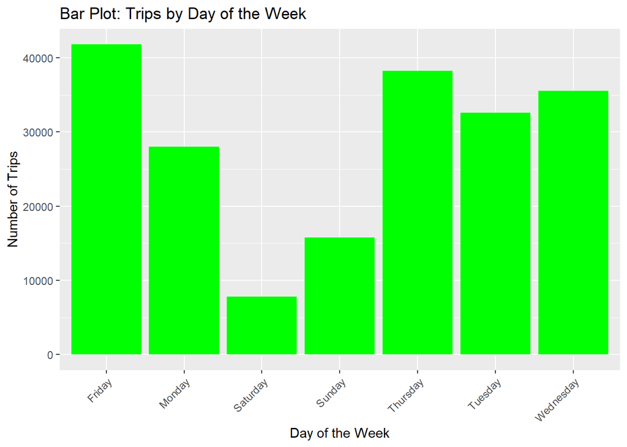

```r
# Bar plot to explore the distribution of trips by day of the week
ggplot(sampled_data_training, aes(x = day_of_week)) +
  geom_bar(fill = "green") +
  labs(title = "Bar Plot: Trips by Day of the Week",
       x = "Day of the Week",
       y = "Number of Trips") +
  theme(axis.text.x = element_text(angle = 45, hjust = 1))
```

```r
numeric_columns <- sampled_data_training[sapply(sampled_data_training, is.numeric)]
cor(numeric_columns)
```

```
##                       passenger_count trip_distance  fare_amount        extra
## passenger_count           1.000000000   0.015325269  0.013198140 -0.003113410
## trip_distance             0.015325269   1.000000000  0.921766141 -0.070092350
## fare_amount               0.013198140   0.921766141  1.000000000 -0.092643959
## extra                    -0.003113410  -0.070092350 -0.092643959  1.000000000
## mta_tax                   0.004912767  -0.187541749 -0.282944743  0.034943596
## tip_amount                0.001290254   0.572454920  0.593814701 -0.033366640
## tolls_amount              0.011291706   0.553577458  0.537611929 -0.071048862
## improvement_surcharge    -0.002010955   0.001489049  0.003686591  0.004123098
##                            mta_tax   tip_amount tolls_amount
## passenger_count        0.004912767  0.001290254  0.011291706
## trip_distance         -0.187541749  0.572454920  0.553577458
## fare_amount           -0.282944743  0.593814701  0.537611929
## extra                  0.034943596 -0.033366640 -0.071048862
## mta_tax                1.000000000 -0.171000489 -0.311414842
## tip_amount            -0.171000489  1.000000000  0.394124994
## tolls_amount          -0.311414842  0.394124994  1.000000000
## improvement_surcharge  0.039684415  0.002279046  0.000853292
##                       improvement_surcharge
## passenger_count                -0.002010955
## trip_distance                   0.001489049
## fare_amount                     0.003686591
## extra                           0.004123098
## mta_tax                         0.039684415
## tip_amount                      0.002279046
## tolls_amount                    0.000853292
## improvement_surcharge           1.000000000
```

**Modelling**

```r
model <- lm(tip_amount ~ ., data = sampled_data_training)
predictions <- predict(model, newdata = sampled_data_testing)
model
```

```
##
## Call:
## lm(formula = tip_amount ~ ., data = sampled_data_training)
##
## Coefficients:
##                   (Intercept)                      VendorID2
##                      1.835895                       0.004012
##               passenger_count                  trip_distance
##                     -0.005840                       0.120931
##                   RatecodeID2                    RatecodeID3
##                     -0.064014                       0.284593
##                   RatecodeID4                    RatecodeID5
##                     -0.167244                      -1.909126
##                   RatecodeID6            store_and_fwd_flagY
##                      0.915709                       0.004477
##                 payment_type2                  payment_type3
##                     -2.606445                      -2.802556
##                 payment_type4                    fare_amount
##                     -2.823888                       0.088319
##                         extra                        mta_tax
##                      0.038578                      -1.836157
##                  tolls_amount          improvement_surcharge
##                      0.131689                      -0.482050
##   pickup_time_categoryEvening    pickup_time_categoryMorning
##                     -0.212943                       0.017340
##     pickup_time_categoryNight   dropoff_time_categoryEvening
##                     -0.267057                       0.190167
##  dropoff_time_categoryMorning     dropoff_time_categoryNight
##                     -0.097428                       0.196848
##             day_of_weekMonday            day_of_weekSaturday
##                      0.017046                       0.110580
##             day_of_weekSunday            day_of_weekThursday
##                     -0.098241                       0.046930
##            day_of_weekTuesday           day_of_weekWednesday
##                      0.058314                       0.047356
##          pickup_locationBronx       pickup_locationManhattan
##                      0.529971                       0.530686
##         pickup_locationQueens        pickup_locationBrooklyn
##                      0.617711                       0.608920
##  pickup_locationStaten Island          dropoff_locationBronx
##                      0.062472                      -0.077636
##     dropoff_locationManhattan         dropoff_locationQueens
##                     -0.163060                      -0.132168
##      dropoff_locationBrooklyn  dropoff_locationStaten Island
##                     -0.411100                      -1.042185
```

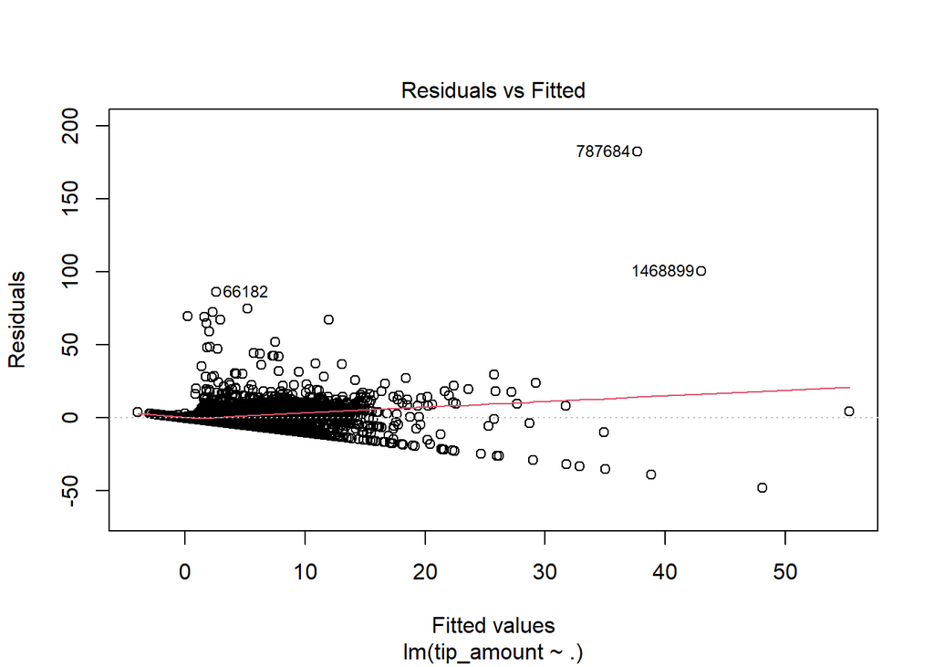

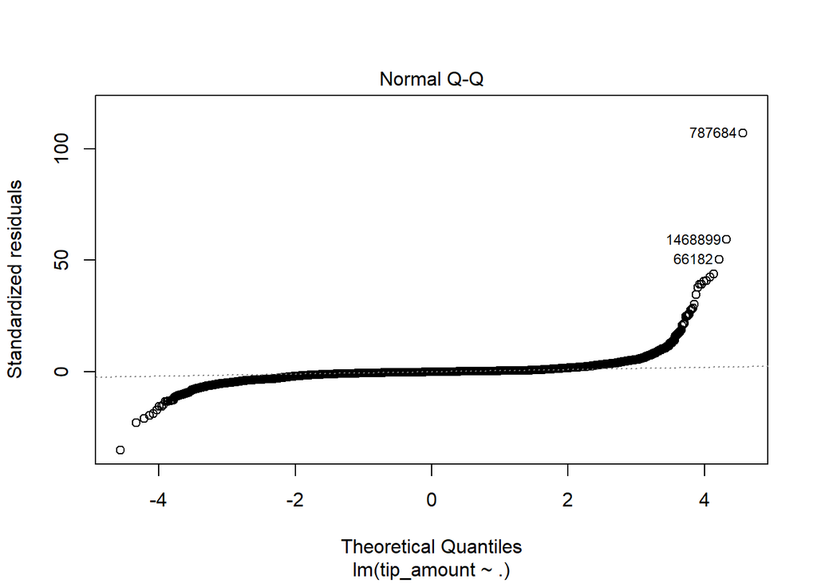

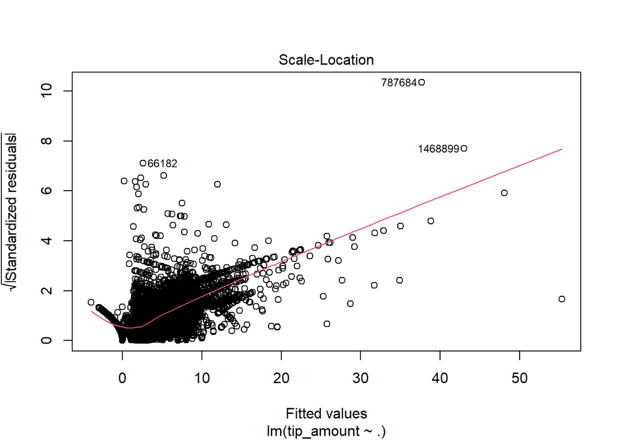

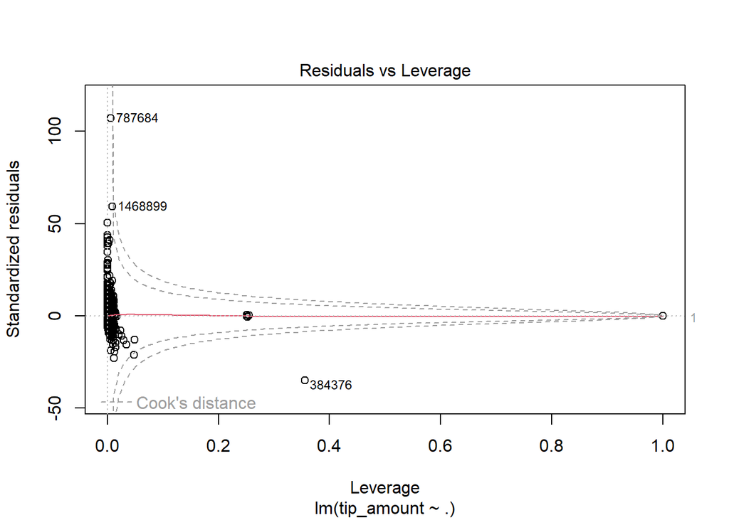

```r
plot(model)
```

```r
mse <- mean((sampled_data_testing$tip_amount - predictions)^2)
mse
```

```
## [1] 2.565746
```

The intercept is 1.836. This is the estimated tip amount when all other predictors are zero.Each additional passenger is associated with a decrease of 0.0058 units in the predicted tip amount.If store_and_fwd_flag is ‘Y’, the predicted tip amount increases by 0.0045 units.

Here, if we observe the residuals vs fitted plot, we observe that the data is more or less near the red base line which is slightly tilted. We are also able to spot some outliers here.In the Normal Q-Q plot, the data is mostly aligned to the reference quantile line which almost flat. We had observed earlier that the tip amount distribution is right-skewed which might be the reason for this. In the case of Scale-location plot, we can see that the variance is not constant in the data.For Residuals vs Leverage plot, it is evident that not all the data points lie in the contours, indicating the outliers of the sample.

**Summary Report**

**Data Cleaning -** The cleaning process involved handling missing values, removing negative fare amounts, and filtering out inconsistent or invalid data.Geographical coordinates were cleaned to ensure they fall within valid ranges.Categorical variables were appropriately converted, and new features like time categories and day of the week were created.

**Exploratory Data Analysis (EDA) -** EDA included visualizations to understand relationships between variables.Scatter plots, box plots, histograms, and bar plots provided insights into the distribution and relationships in the data.Correlation analysis revealed associations between numerical variables.

**Sampling -** Random samples were taken from the cleaned datasets for training and testing purposes. The sample sizes were 10% of the cleaned data for both training and testing.

**Modelling -** A linear regression model was constructed to predict tip amounts based on various features. The model included predictors such as trip distance, payment type, day of the week, etc. The model performance was evaluated using the mean squared error (MSE) on the testing data.

**Model Interpretation -** The intercept of 1.836 represents the estimated tip amount when all other predictors are zero.The coefficients provide insights into the impact of each predictor on the predicted tip amount.For example, an additional passenger is associated with a decrease of 0.0058 units in the predicted tip amount.

**Model Performance -** The Mean Squared Error (MSE) was calculated on the testing data to assess model performance which here is 2.565. Residual plots were examined to check for model assumptions and identify potential outliers.The residuals vs fitted plot showed some outliers, indicating areas where the model could be improved. Normal Q-Q plot and Scale-location plot provided insights into the distribution and variance of residuals. Residuals vs Leverage plot highlighted potential influential data points.

The model provides a starting point for predicting tip amounts based on the given features. Model performance, as indicated by the MSE, gives a measure of the prediction accuracy. Areas for improvement include handling outliers and exploring more advanced modeling techniques like regularization (e.g., Lasso) to enhance predictive accuracy and reduce the number of variables.